# Predykcja zadowolenia studentów z e-nauczania podczas pandemii COVID-19

Magdalena Marecik

29 11 2021

## Wstęp

Wybuch pandemii COVID-19 w marcu 2020 roku spowodował konieczność wprowadzenia szeregu ograniczeń, mających na celu zahamowanie rozprzestrzeniania się zakażeń. Wprowadzenie lock-down’u i ograniczenie kontaktów społecznych zmieniły dotychczasowe życie prywatne i zawodowe wielu ludzi. Restrykcje dotknęły również instytucji szkolnictwa wyższego, które z dnia na dzień stanęły przed koniecznością wdrożenia zdalnego systemu nauczania. Zajęcia dotychczas prowadzone stacjonarnie zostały przeniesione na różnego rodzaju platformy e-learningowe, aby studenci i pracownicy uczelni mogli pozostać w domach. Przejście na zdalny system nauki postawiło wiele wyzwań zarówno przed studentami jak i wykładowcami. Wiązały się one z czysto technicznymi aspektami takiej formy nauczania, ale również z czynnikami psychologicznymi i pedagogicznymi. Znaczna część studentów straciła możliwość nawiązywania kontaktów towarzyskich z rówieśnikami, a nauka z domu nie była czynnikiem motywującym do nauki. Z drugiej strony e-learning pozwolił zaoszczędzić wielu osobom znaczną ilość czasu i pieniędzy, przez brak konieczności dojazdów i przeprowadzki do miast, w których studiowali. Istotną kwestią jest również pytanie o to jak efektywne było studiowanie, tzn. zdobywanie wiedzy na odległość w porównaniu z nauką tradycyjną. Wszystkie te i inne czynniki miały wpływ na satysfakcję studentów z e-learningu, która według [(ankiety)](https://www.wework.com/ideas/research-insights/research-studies/the-impact-of-covid-19-on-the-university-student-experience) przeprowadzonej przez WeWork na wiosnę 2020 roku spadła o ponad 27%.

## Cel projektu

Głównym celem poniższego badania jest predykcja zadowolenia studentów z e-nauczania za pomocą wybranych technik uczenia statystycznego, takich jak naiwny klasyfiaktor Bayes’a, drzewa decyzyjne oraz maszyna wektorów nośnych, a następnie porównanie dokładności zbudowanych modeli. Badanie ma na celu zweryfikować, czy według studentów można uznać, że e-learning na uczelniach wyższych odniósł sukces oraz jakie czynniki wpływają na stopień zadowolenia studentów z e-nauczania. W pracy zostanie również dokonana analiza doświadczeń studentów związanych ze studiowaniem zdalnym oraz próba podziału respondentów na grupy o podobnych przekonaniach na ten temat za pomocą analizy skupień.

## Opis danych

Dane wykorzystane w badaniu pochodzą z ankiety przeprowadzonej wśród studentów polskich uczelni. Dotyczą doświadczeń studentów związanych ze studiowaniem zdalnie w okresie od marca 2020 do czerwca 2021 roku. Ankieta została udostępniona w sierpniu 2021 roku i zamknięta w listopadzie 2021 roku. Składa się z metryczki zawierającej 5 pytań jednokrotnego wyboru, 7 pytań dotyczących doświadczeń związanych z nauczaniem zdalnym i odpowiedziami w siedmiostopniowej skali Likerta oraz pytania o to, czy osoba jest ogólnie zadowolona z e-nauczania (odpowiedzi „tak” lub „nie”). Pytania oraz możliwe odpowiedzi zostały wypisane poniżej. Ankietę wypełniło łącznie 228 studentów.

1. Metryczka
   - Tryb studiów
     - stacjonarne
     - niestacjonarne
   - Rok studiów
     - I
     - II
     - III
     - IV
     - V i wyżej
   - Rodzaj studiów
     - Ścisłe, techniczne
     - Medyczne, przyrodnicze
     - Humanistyczne, społeczne, artystyczne
     - Ekonomiczne, biznesowe
   - Płeć
     - Kobieta
     - Mężczyzna
   - Miejsce zamieszkania podczas pandemii
     - Miasto powyżej 100 tys. Mieszkańców
     - Miasto poniżej 100 tys. Mieszkańców
     - Wieś
2. Pytania o doświadczenia związane ze studiowaniem zdalnym, odpowiedzi w 7-stopniowej skali Likerta
   - Uważam, ze poziom mojej wiedzy byłby większy, gdyby zajęcia odbywały się stacjonarnie
   - Podczas nauki zdalnej miałem(-am) większy problem ze skupieniem lub znalezieniem motywacji do nauki
   - Odczuwałem dyskomfort związany z koniecznością samodzielnego wykonywania większości zadań
   - Prowadzący dostosowali formę zajęć i zaliczeń do realiów zdalnego nauczania
   - Preferuje tradycyjna formę nauczania
   - Nauka zdalna dala mi możliwość pogodzenia ze studiami innych obowiązków (np. pracy)
   - Chciał(a)bym, aby po pandemii tradycyjne nauczanie było uzupełniane o zajęci w formie zdalnej
3. Pytania o ogólne zadowolenie z e-nauczania
   - Ogólnie rzecz ujmując, pozytywnie oceniam efektywność e-nauczania
     - Tak
     - Nie

## Wstępna analiza odpowiedzi respondentów

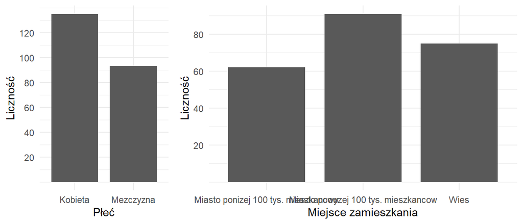

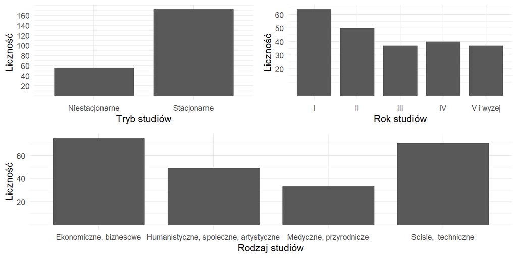

Odpowiedzi studentów na pytania dotyczące nauki on-line zostały przedstawione na wykresach słupkowych poniżej. Z odpowiedzi ankietowanych wynika, że nie można jednoznacznie stwierdzić, że e-learningu osiągnął sukces. Liczba ankietowanych zadowolonych i niezadowolonych ze zdalnego nauczania jest bardzo zbliżona. Jednocześnie duża skośność lewostronna pierwszego, drugiego, piątego i siódmego wykresu wskazują, że znaczna część studentów miała problem ze znalezieniem motywacji i uważa, że ich wiedza byłaby większa, gdyby studiowali stacjonarnie. Dodatkowo dowiadujemy się, że większość studentów preferuje tradycyjną formę nauczania, jednak chciałaby, aby w przyszłości zajęcia prowadzone były hybrydowo. Bez wątpienia jest tak z powodu dużej wygody jaką niesie ze sobą nauka zdalna oraz charakteru niektórych zajęć. Okazuje się, że wiele studentów dzięki nauczaniu zdalnemu i większej ilości wolnego czasu miało możliwość pogodzenia ze studiami innych obowiązków. Odpowiedzi na pytanie o stres związany z większą ilością samodzielnej nauki są bardzo zróżnicowane – każda liczba na skali ma zbliżoną liczbę odpowiedzi. Z ankiety wynika, że większość prowadzących w zadowalającym stopniu dostosowała formę prowadzonych zajęć do realiów zdalnego nauczania.

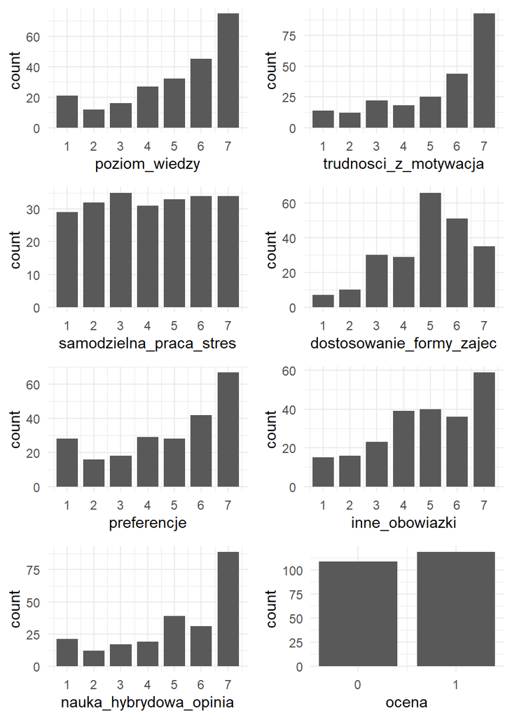

Na poniższym wydruku widzimy podstawowe statystyki dla poszczególnych zmiennych z wartościami w skali Likerta. Wartości statystyk potwierdzają wcześniejsze obserwacje dokonane na podstawie wykresów.

```
##                          vars   n mean   sd median trimmed  mad min max range
## poziom_wiedzy               1 228 5.07 1.97      6    5.32 1.48   1   7     6
## trudnosci_z_motywacja       2 228 5.33 1.91      6    5.61 1.48   1   7     6
## samodzielna_praca_stres     3 228 4.07 1.99      4    4.09 2.97   1   7     6
## dostosowanie_formy_zajec    4 228 4.89 1.54      5    4.99 1.48   1   7     6
## preferencje                 5 228 4.79 2.09      5    4.97 2.97   1   7     6
## inne_obowiazki              6 228 4.83 1.85      5    4.99 1.48   1   7     6
## nauka_hybrydowa_opinia      7 228 5.16 2.00      6    5.43 1.48   1   7     6
## ocena                       8 228 0.52 0.50      1    0.53 0.00   0   1     1
##                           skew kurtosis   se
## poziom_wiedzy            -0.78    -0.59 0.13
## trudnosci_z_motywacja    -0.92    -0.42 0.13
## samodzielna_praca_stres  -0.03    -1.26 0.13
## dostosowanie_formy_zajec -0.56    -0.30 0.10
## preferencje              -0.56    -1.02 0.14
## inne_obowiazki           -0.49    -0.81 0.12
## nauka_hybrydowa_opinia   -0.82    -0.58 0.13
## ocena                    -0.09    -2.00 0.03
```

Warto zobaczyć, jak poszczególne grupy studentów odpowiadały na ostatnie pytanie biorąc pod uwagę ich płeć, miejsce zamieszkania podczas pandemii oraz informacje o studiach. Z analizy wynika, że kobiety częściej niż mężczyźni deklarują zadowolenie z e-learningu. Odsetek osób zadowolonych ze zdalnego nauczania jest zbliżony wśród osób mieszkających w małych i dużych miastach (0.58, 0.57), a mniejszy u osób, które w czasie pandemii mieszkały na wsi (0.41). Zapewne wiąże się to z faktem, że osoby mieszkające na wsi były podczas lock-down’u bardziej narażone na izolację. Studiujący zaocznie oraz na wyższych latach są częściej zadowolone z e-learningu niż studiujący na I czy II roku oraz dziennie. Największy odsetek negatywnych odpowiedzi na ostatnie pytanie występuje wśród studentów kierunków ścisłych i technicznych. Wynika to ze specyfiki tego rodzaju studiów, ponieważ zajęcia na nich mają częściej charakter praktyczny i odbywanie ich zdalnie jest nieefektywne.

## Macierz korelacji

Spójrzmy na macierz korelacji tau-Kendalla pomiędzy zmiennymi. Tau Kendalla jest miarą monotonicznej zależności dwóch zmiennych losowych. Wszystkie zmienne objaśniające są skorelowane ze zmienną zależną na poziomie co najmniej 0.3. Największa współczynnik korelacji wynoszący 0.54 występuje między oceną, a chęcią nauki w systemie hybrydowym. Wysokie korelacje występują również pomiędzy niektórymi zmiennymi objaśniającymi. Przykładem jest tutaj zmienna dotycząca problemów z motywacją oraz poziomem wiedzy – są one skorelowane bardziej ze sobą niż z Y. Aby informacje niesione przez poszczególne zmienne nie powielały się, zdecydowano, że modele będą budowane tylko na części pytań. Odrzucone zostaną pytania dotyczące preferencji oraz trudności z motywacją, ponieważ posiadają one dość wysokie współczynniki korelacji z innymi zmiennymi objaśniającymi.

```
##                          poziom_wiedzy trudnosci_z_motywacja
## poziom_wiedzy                1.0000000             0.4753958
## trudnosci_z_motywacja        0.4753958             1.0000000
## samodzielna_praca_stres      0.3335390             0.2959000
## dostosowanie_formy_zajec    -0.1736722            -0.1704415
## preferencje                  0.4997866             0.3963113
## inne_obowiazki              -0.2054584            -0.1530195
## nauka_hybrydowa_opinia      -0.3058697            -0.2532489
## ocena                       -0.3968855            -0.3396535
##                          samodzielna_praca_stres dostosowanie_formy_zajec
## poziom_wiedzy                          0.3335390               -0.1736722
## trudnosci_z_motywacja                  0.2959000               -0.1704415
## samodzielna_praca_stres                1.0000000               -0.3131789
## dostosowanie_formy_zajec              -0.3131789                1.0000000
## preferencje                            0.3419836               -0.1918489
## inne_obowiazki                        -0.2813374                0.1604612
## nauka_hybrydowa_opinia                -0.3114608                0.2032025
## ocena                                 -0.4203718                0.3000551
##                          preferencje inne_obowiazki nauka_hybrydowa_opinia
## poziom_wiedzy              0.4997866     -0.2054584             -0.3058697
## trudnosci_z_motywacja      0.3963113     -0.1530195             -0.2532489
## samodzielna_praca_stres    0.3419836     -0.2813374             -0.3114608
## dostosowanie_formy_zajec  -0.1918489      0.1604612              0.2032025
## preferencje                1.0000000     -0.3077233             -0.4764161
## inne_obowiazki            -0.3077233      1.0000000              0.3666225
## nauka_hybrydowa_opinia    -0.4764161      0.3666225              1.0000000
## ocena                     -0.4937108      0.4076139              0.5470440
##                               ocena
## poziom_wiedzy            -0.3968855
## trudnosci_z_motywacja    -0.3396535
## samodzielna_praca_stres  -0.4203718
## dostosowanie_formy_zajec  0.3000551
## preferencje              -0.4937108
## inne_obowiazki            0.4076139
## nauka_hybrydowa_opinia    0.5470440
## ocena                     1.0000000
```

Ostatecznie do dalszej analizy zostana wykorzystane nastepujace zmienne:

- Uwazam, ze poziom mojej wiedzy bylby wiekszy, gdyby zajecia odbywaly sie stacjonarnie (poziom_wiedzy)
- Odczuwalem stres zwiazany z koniecznoscia samodzielnego wykonywania wiekszosci zadan (samodzielna_praca_stres)
- Prowadzacy dostosowali forme zajec i zaliczen do realiow zdalnego nauczania (dostosowanie_formy_zajec)
- Nauka zdalna dala mi mozliwosc pogodzenia ze studiami innych obowiazkow (np. pracy) (inne_obowiazki)
- Chcial(a)bym, aby po pandemii tradycyjne nauczanie bylo uzupelniane o zajecia w formie zdalnej (nauka_hybrydowa_opinia)
- Ogolnie rzecz ujmujac, pozytywnie oceniam efektywnosc e-nauczania (ocena)

## Analiza skupień

Na omawianych danych zostanie przeprowadzona analiza skupień w celu wykrycia grup studentów o podobnych doświadczeniach związanych z e-learningiem. Do przeprowadzenia grupowania wybrano metodę k-modes, która jest rozszerzeniem metody k-średnich dla zmiennych kategorycznych. Algorytm k-modes zamiast dystansu używa miary odmienności, która jest przedstawiona jako suma niedopasowań poszczególnych zmiennych kategorycznych pomiędzy obserwacjami. Działanie algorytmu polega na wylosowaniu k unikalnych obserwacji ze zbioru jako początkowych k-dominant, a następnie obliczenie miar odmienności pomiędzy dominantami a wszystkimi obserwacjami. Obserwacje są przypisywane do najbardziej podobnej dominanty, a następnie wybierane jest nowe k dominant dla każdej grupy. Kroki te są powtarzane do póki przydział do grup przestanie się zmieniać. Przed zastosowaniem metody k-modes należy podać liczbę klastrów, do których mają zostać przydzielone obserwacje. W celu dobrania najlepszej liczby grup zastosowane metodę łokcia. Metoda zakłada wybranie takiej liczby grup, dla której nastąpił największy “skok” funkcji WSS, czyli spadek sumy miary odmienności pomiędzy obiektami a dominantą w każdym z klastrów. Wykres zmienności wewnątrzgrupowej w zależności od k przedstawia poniższy wykres. Zdecydowano podzielić obserwacje na 5 klastrów, ponieważ dla k=5 nastąpił znaczny spadek funkcji WSS. Nie chcemy również dzielić obserwacji na zbyt wiele grup, ponieważ utrudniłoby to dalszą wizualizację i analizę.

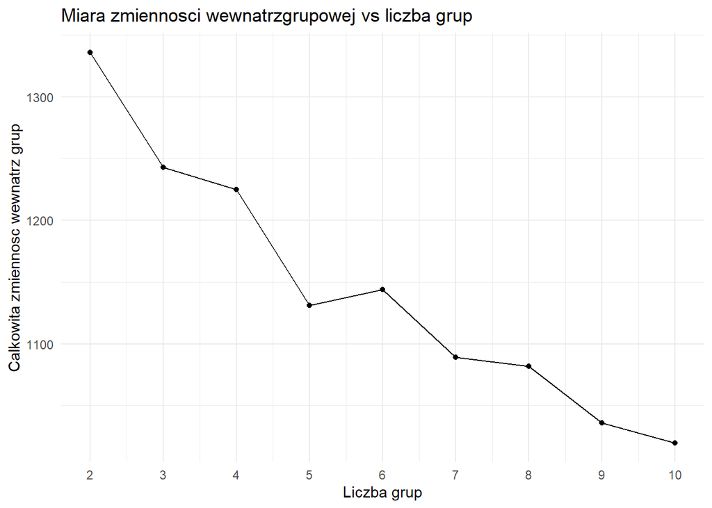

Analiza skupień metodą k-modes pozwoliła stworzyć 5 grup respondentów, którzy udzielali podobnych odpowiedzi na pytania w ankiecie. W pierwszej grupie przeważają studenci kierunków humanistycznych, którzy udzielali wysokich odpowiedzi na pytanie o dostosowanie formy zajęć do realiów zdalnego nauczania oraz możliwości pogodzenia ze studiami innych obowiązków. Respondenci w tej grupie chcą, aby w przyszłości tradycyjna forma edukacji była uzupełniana o zajęcia w formie zdalnej i w znacznej większości pozytywnie oceniają efektywność e-learningu. W drugiej grupie dominują mężczyźni, mieszkający w dużych miastach, studiujący kierunki techniczne i ekonomiczne, którzy w większej części mają negatywne odczucia związane z e-nauczaniem. Trzecia grupa składa się w znacznej mierze ze studentek I roku studiów technicznych, mieszkających na wsi, które w zdecydowanej większości (35 z 36 ankietowanych) odpowiedziały, że nie są zadowolone z e-learningu. Czwarty klaster to w szczególności studentki kierunków ekonomicznych zadowolone z e-learningu. Na klaster piąty składają się w większości studenci, którzy nie odczuwali dyskomfortu z koniecznością samodzielnego wykonywania większości zadań, a dzięki nauce zdalnej mieli możliwość pogodzenia nauki z innymi obowiązkami. Tym samym pozytywnie oceniają efektywność zdalnego nauczania. Uśrednione odpowiedzi wewnątrz wszystkich pięciu grup na pytania dotyczące e-learningu zostały przedstawione na wykresie PCP - wykresie współrzędnych równoległych. Wartości zmiennych zostały automatycznie zeskalowane do jednego zakresu. Wykres PCP w intuicyjny sposób pokazuje, jak kształtowały się odpowiedzi w poszczególnych grupach respondentów.

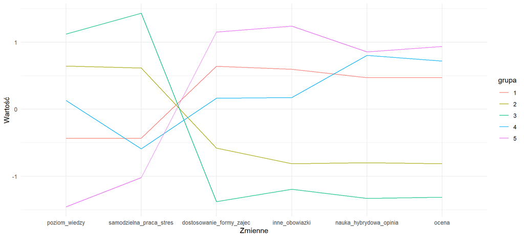

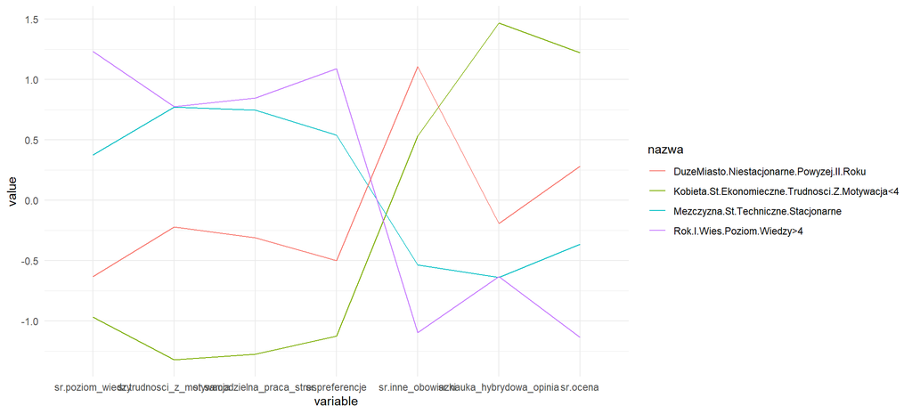

Po wstępnej analizie odpowiedzi, jakich udzielili ankietowani, przechodzimy do kolejnej części badania, czyli budowania modeli mających na celu prognozowanie zadowolenia studentów ze zdalnego nauczania.

## Naiwny klasyfikator Bayes’a

Naiwna klasyfikacja bayesowska jest metodą klasyfikacji, która opera się na regule Bayes’a, zgodnie z którą obiekt X klasyfikujemy jako pochodzący z klasy C, jeśli prawdopodobieństwo bycia w stanie X pod warunkiem przynależności do klasy C jest największe spośród wszystkich klas. Twierdzenie Bayes’a wyraża się wzorem:

$$P(C\mid X) = \frac{P(X\mid C)\cdot P(C)}{P(X)}$$

Metoda wiąże się z dużym uproszczeniem, gdyż zakłada, że zmienne opisujące obiekt są niezależne. Założenie to bardzo upraszcza złożoność modelu, szczególnie dla dużych zbiorów danych, ponieważ pozwala zastosować poniższy wzór:

$$P(A_1\cap \cdots \cap A_k) = P(A_1)\cdot {\dots} \cdot P(A_k)$$

Dzięki temu licznik w pierwszym wzorze można przekształcić do prostej postaci, ostatecznie otrzymując:

$$P(C\mid X_1 \dots X_k) = \frac{P(X_1\mid C)\cdot {\dots} \cdot P(X_k\mid C) \cdot P(C)}{P(X_1 \dots X_k)}$$

Ppowyższe prawdopodobieństwa możemy w łatwy sposób estymować, opierając się na zbiorze treningowym. Wystarczy obliczyć częstość występowania obiektów z klasy $C_i$ posiadających wartość $s_j$ dla i-tej zmiennej kategorycznej.

Chcemy stworzyć model, który na podstawie odpowiedzi udzielonych w ankiecie (p=5, pod uwage będą brane tylko pytania z odpowiedziami w skali Likerta), będzie stwierdzał, czy dany student jest zadowolony z całokształtu zdalnego nauczania. W tym celu dzielimy dane na zbiór uczący (161 obserwacji) oraz testowy (67 obserwacji) w stosunku 7:3. W oparciu o zbiór treningowy konstruujemy naiwny klasyfikator Bayes’a. Jako procedurę oceny jakości modelu zastosowano powtórzoną 3 razy 10-krotną walidację krzyżową.

```r
set.seed(0)
control <- trainControl(method="repeatedcv", number=10, repeats=3)
nbc <- train(ocena ~ .,
             data = uczacy.elearning,
             method = 'nb',
             trControl = control)
nbc
```

```
## Naive Bayes
##
## 161 samples
##   5 predictor
##   2 classes: '0', '1'
##
## No pre-processing
## Resampling: Cross-Validated (10 fold, repeated 3 times)
## Summary of sample sizes: 146, 145, 145, 145, 144, 146, ...
## Resampling results across tuning parameters:
##
##   usekernel  Accuracy   Kappa
##   FALSE      0.8240850  0.6476882
##    TRUE      0.8007516  0.5978123
##
## Tuning parameter 'fL' was held constant at a value of 0
## Tuning
##  parameter 'adjust' was held constant at a value of 1
## Accuracy was used to select the optimal model using the largest value.
## The final values used for the model were fL = 0, usekernel = FALSE and adjust
##  = 1.
```

```
## Confusion Matrix and Statistics
##
##           Reference
## Prediction  0  1
##          0 28  3
##          1  4 32
##
##                Accuracy : 0.8955
##                  95% CI : (0.7965, 0.957)
##     No Information Rate : 0.5224
##     P-Value [Acc > NIR] : 6.751e-11
##
##                   Kappa : 0.7903
##
##  Mcnemar's Test P-Value : 1
##
##             Sensitivity : 0.8750
##             Specificity : 0.9143
##          Pos Pred Value : 0.9032
##          Neg Pred Value : 0.8889
##              Prevalence : 0.4776
##          Detection Rate : 0.4179
##    Detection Prevalence : 0.4627
##       Balanced Accuracy : 0.8946
##
##        'Positive' Class : 0
##
```

Na powyższym wydruku widzimy, że zastosowana metoda ‘nb’ posiada trzy hiperparametry (parametry kontrolujące proces uczenia modelu), które należałoby poddać procesowi dostrajania. Modele, których hiperparametry zostały źle dobrane mogą działać podobnie jak funkcja losowa, natomiast dobrze skonfigurowane często dają bardzo dobrą dokładność predykcji. Dla funkcji train() w metodzie naiwnej klasyfikacji Bayes’a możemy wyróżnić trzy hiperparametry:

- fL (korekta Laplace’a – stosowana przy problemie dokładności szacowanych prawdopodobieństw dla mało licznych klas)
- usekernel (oszacowanie jądrowe – funkcja rozkładu wartości cechy jest przybliżana przez tzw. oszacowanie jądrowe, a nie przez pojedynczy rozkład normalny)
- adjust (dostosowanie szerokości pasma gęstości jądra - bandwidth, im większe tym bardziej elastyczne oszacowanie)

W kolejnym kroku został przeprowadzony tuning hiperparametrów modelu.

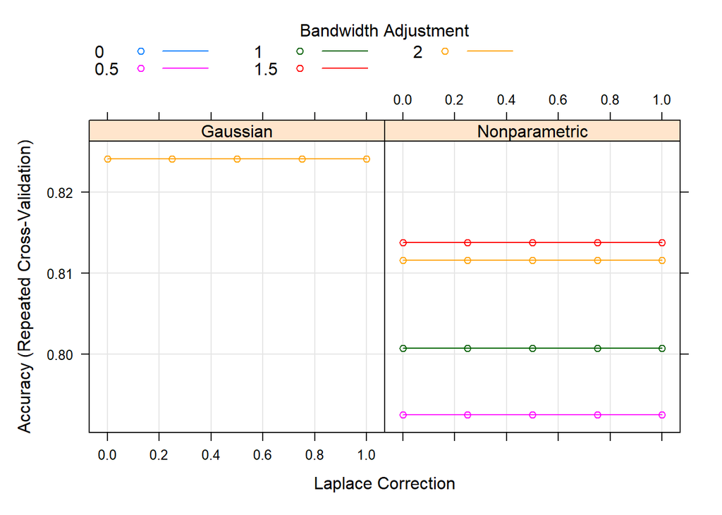

```r
search.grid <- expand.grid(usekernel = c(TRUE, FALSE),
                           fL = seq(0, 1, 0.25),
                           adjust = seq(0, 2, 0.5))
set.seed(0)
nbc.tun <- train( ocena ~ .,
              data=uczacy.elearning,
              method = "nb",
              trControl = control,
              tuneGrid = search.grid)
plot(nbc.tun)
```

Najlepszą dokładność predykcji otrzymujemy dla modelu bez korekty Laplace’a (brak wpływu na jakość predykcji) i oszacowania gęstości jądra, czyli dla wartości hiperparametrów, który zostały domyślnie użyte w pierwszym modelu. Tuning hiperparametrów nie pomógł nam w znalezieniu modelu o lepszych własciwościach prognostycznych. W kolejnych krokach spróbujemy zbudować szereg klasyfikatorów opartych na drzewach decyzyjnych.

## Modele oparte na drzewach decyzyjnych

Metody uczenia statystycznego oparte na drzewach decyzyjnych mają zastosowanie w rozwiązywaniu zarówno problemów regresyjnych jak i klasyfikacyjnych. Ich idea polega na podziale przestrzeni zmiennych objaśniających według określonych reguł, których spełnienie lub nie decyduje o zaklasyfikowaniu danego obiektu do konkretnej klasy zmiennej zależnej (lub o jej wartości w problemie regresyjnym). Węzły w drzewach decyzyjnych odpowiadają testom na wybranych zmiennych, a krawędzie ich wartościom. Każdy liść ma przypisaną klasę decyzyjną.

Modele oparte na drzewach decyzyjnych są łatwe w zrozumieniu i interpretacji. Dodatkowym atutem jest ich intuicyjność i prostota wizualizacji, ponieważ mogą w prosty sposób zostać przedstawione za pomocą grafu. Ceną wysokiej interpretowalności drzew decyzyjnych są często gorsze zdolności prognostyczne w porównaniu z innymi metodami uczenia maszynowego. Istnieje jednak szereg metod, których zadaniem jest zwiększenie dokładności predykcji drzew decyzyjnych. Jednymi z takich metod są bagging oraz random forest, które dalej zostały wykorzystane do predykcji zadowolenia studentów z e-learningu.

### Pojedyncze drzewo klasyfikacyjne

Drzewa klasyfikacyjne przydzielają każdą obserwacje do takiej klasy, która w zbiorze uczącym występowała najczęściej w danym regionie. Obszar regionu jest wyznaczany przez reguły na zmiennych objaśniających. Naturalnym kryterium kolejnych podziałów drzewa jest błąd klasyfikacji (classification error rate), będący odsetkiem obserwacji w zbiorze uczącym, które należąc do danego węzła, nie należą jednocześnie do najczęściej występującej w tym węźle klasy.

$$E = 1 - \max_{k}{(\hat{p}_{mk})}$$

$\hat{p}_{mk}$ oznacza odsetek obserwacji treningowych w m-tym regionie przynależących do k-tej klasy. Błąd klasyfikacji nie jest jednak wystarczająco czuły na wzrost drzewa, dlatego w praktyce stosuje sie go częściej do oceny dokładności predykcji. Jako kryterium decydujące o kolejnych podziałach drzewa częściej stosowany jest natomiast index Giniego, który mierzy całkowitą wariancję we wszystkich K klasach. Niskie wartości indeksu wskazują, że w węźle dominują obserwacje przynależące do tej samej klasy.

$$G = \sum^{K}_{k=1}{\hat{p}_{mk}(1-{{\hat{p}_{mk}}})}$$

Alternatywą dla indeksu Giniego jest entropia, która podobnie przyjmuje niższe wartości, jeśli w węźle dominują obserwacje z tej samej klasy.

$$D = -\sum^{K}_{k=1}{\hat{p}_{mk}\log{{\hat{p}_{mk}}}}$$

Entropia i indeks Giniego są używane do mierzenia jakości poszczególnych podziałów drzewa. Niestety wykorzystywana w projekcie funkcja train() z pakietu caret nie umożliwia wyboru indeksu Giniego i entropii jako kryterium jakości klasyfikatora, dlatego najlepsze modele są wybiearne na podstawie dokładności predykcji.

Poniższy wydruk przedstawia informacje dotyczące drzewa klasyfikacyjnego zbudowanego na omawianym zbiorze danych. W modelu występuje jeden hiperparametr - complexity parameter, stanowiący warunek zatrzymania podziału drzewa. Parametr pomaga zatem wybrać odpowiedni rozmiar drzewa. Wiąże się on ze złożonością kosztową modelu wyrażoną jako

$$\sum_{Terminal{\ }Nodes}{Misclass_i} \ + \alpha\cdot(Splits)$$

Parametr jest zatem kosztem nakładanym przy każdym dodatkowym podziale drzewa. Cp jest powiązany z parametrem $\alpha$ i może zostać dobrany w procesie walidacji krzyżowej. Dla poniższego modelu była to 10-krotna walidacja krzyżowa powtórzona trzykrotnie.

```r
control <- trainControl(method="repeatedcv", number=10, repeats=3)
set.seed(0)
tree <- train(ocena ~ .,
              data = uczacy.elearning,
              method = "rpart",
              trControl = control,
              tuneGrid = expand.grid(cp = seq(0,0.1,0.01)))
tree
```

```
## CART
##
## 161 samples
##   5 predictor
##   2 classes: '0', '1'
##
## No pre-processing
## Resampling: Cross-Validated (10 fold, repeated 3 times)
## Summary of sample sizes: 146, 145, 145, 145, 144, 146, ...
## Resampling results across tuning parameters:
##
##   cp    Accuracy   Kappa
##   0.00  0.7638644  0.5223446
##   0.01  0.7598203  0.5141613
##   0.02  0.7510866  0.4966075
##   0.03  0.7248611  0.4463438
##   0.04  0.7205719  0.4375424
##   0.05  0.7122059  0.4202703
##   0.06  0.7248448  0.4449110
##   0.07  0.7290114  0.4531099
##   0.08  0.7312337  0.4575326
##   0.09  0.7390768  0.4718410
##   0.10  0.7390768  0.4718410
##
## Accuracy was used to select the optimal model using the largest value.
## The final value used for the model was cp = 0.
```

Błąd walidacji krzyżowej, będący kryterium wyboru parametru cp, stanowi dobre przybliżenie błędu predykcji na zbiorze testowym. Dla powyższego modelu został wybrany parametr cp=0, ponieważ otrzymano dla niego największą dokładność predykcji. Dokładność predykcji na zbiorze uczącym dla zbudowanego drzewa wynosi 84.47%, a na zbiorze testowym 82.09%, co stanowi dobry wynik. Błąd walidacji krzyżowej kolejny raz okazał się zawyżony w stosunku do błędu predykcji na zbiorze testowym.

Uzyskane drzewo zostało przedstawione graficznie na poniższym wykresie. Widzimy, że pierwszy podział drzewa dokonał się ze względu na pytanie o chęć uzupełniania po pandemii tradycyjnej formy zajęć nauczaniem on-line. Negatywna odpowiedz na to pytanie (od 1 do 4) gwarantuje, że drzewo zaklasyfikuje taka osobę jako niezadowolona z efektów zdalnego nauczania. Jeśli ankietowany udzielił na pierwsze pytanie odpowiedzi pozytywnej, drzewo weryfikuje opinie na temat tego, czy student uważa, że jego poziom wiedzy byłby większy, gdyby zajęcia odbywały się stacjonarnie. Jeśli ankietowany udzielił odpowiedzi od 1 do 5, zostaje mu zadane pytanie o inne obowiązki w czasie pandemii itd. aż ankietowany zostanie przydzielony do odpowiedniej klasy.

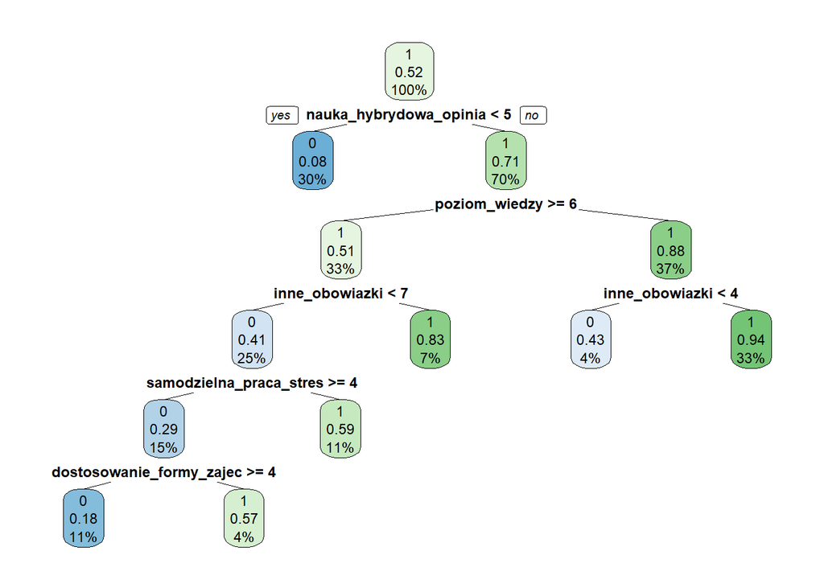

Jedna z wad metod uczenia statystycznego opartych na drzewach decyzyjnych jest ich duża wrażliwość nawet na niewielkie zmiany w danych (metody charakteryzuje wysoka wariancja). Poniższe drzewo zostało zbudowane na innym zbiorze treningowym, co poskutkowało znacznymi zmianami w jego wielkości oraz doborze reguł do kolejnych podziałów drzewa. Istnieją jednak metody oparte na agregacji wielu drzew decyzyjnych, które pozwalają zredukować wysoką wariancję algorytmu i poprawić dokładność predykcji. Jedną z takich metod jest bagging.

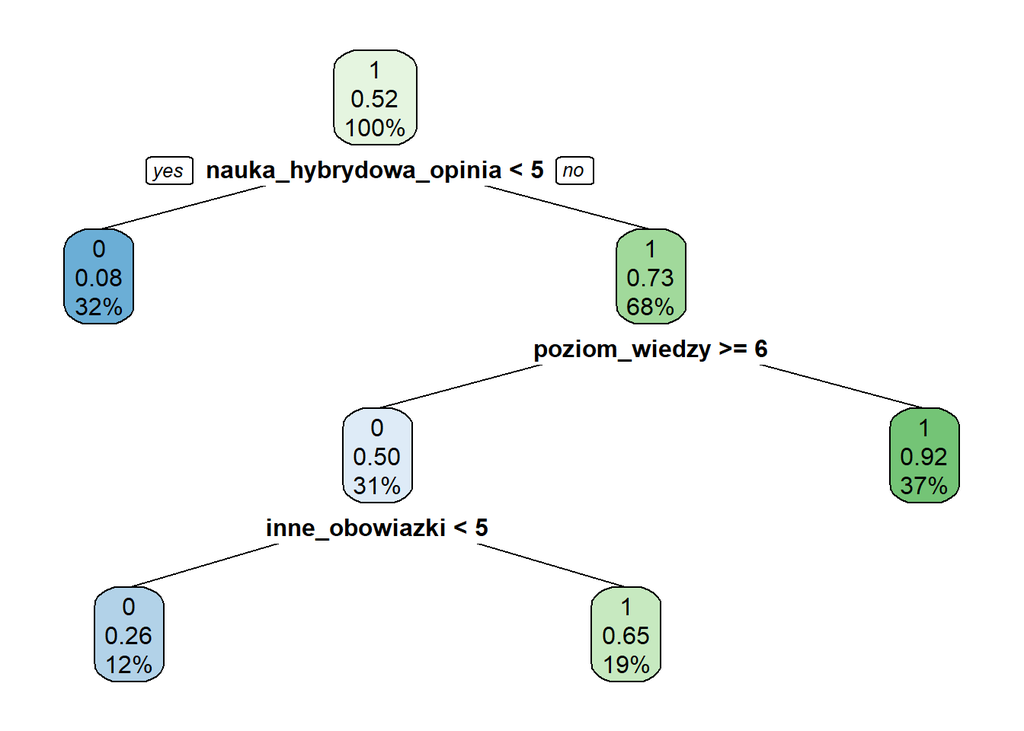

#### Bagging

Jednym ze sposobow redukcji wariancji, a tym samym poprawy dokladnosci predukcji motod ML jest wylosowanie wielu zbiorow uczacych z populacji, zbudowanie na kazdym z nich osobnego modelu, a nastepnie usrednienie wynikow klasyfikacji kazdego z nich. W praktyce nielatwo o dostep do wielu zbiorow uczacych, dlatego zamiast omówionego sposobu stosuje sie metode polegajaca na pobieraniu wielu (B) prob typu bootstrap z pojedynczego zbioru uczacego. Nastepnie na kazdej probce bootstrapowej tworzony jest osobny model. Ostateczny rezultat stanowi usrednienie wszystkich stworzonych modeli. Takie podejscie nosi nazwe bagging’u.

$$\hat{f}_{bag}(x) = \frac{1}{B}\sum^B_{b=1}{\hat{f}^{*b}(x)}$$

W kontekscie drzew decyzyjnych bagging polega na skonstruowaniu B drzew z uzyciem B prob typu boostrap, a nastepnie usrednieniu wynikow (problem regresji) lub wzieciu najczesciej przewidywanej przez drzewa klasy (problem klasyfikacji).

Co ciekawe, duza wartosc parametru B - liczby usrednianych drzew, nie prowadzi do przeuczenia modelu. W praktyce wybiera sie B wystarczajace, aby zwiekszyc dokladnosc predykcji przy jednoczesnym rozsadnym czasie wykonywania obliczen.

Kolejna zaleta baggingu jest fakt, ze pozwala on z duza dokladnoscia przyblizyc blad predykcji na zbiorze testowym. Podczas gdy pojedyncze drzewo jest budowane na probce bootstrapowej, pozostala czesc obserwacji (z reguly okolo 1/3), nazywana OOB (out-of-bag observations), moze posluzyc jako zbior testowy dla tego modelu. Jesli B jest wystarczajaco duze, blad predykcji OOB jest porownywalny z bledem otrzymywanym za pomoca walidacji krzyzowej leave-one-out.

```r
set.seed(9)
bagging <- train( ocena ~ .,
                data = uczacy.elearning,
                  method = "treebag",
                    trControl = control)

bagging
```

```
## Bagged CART
##
## 161 samples
##   5 predictor
##   2 classes: '0', '1'
##
## No pre-processing
## Resampling: Cross-Validated (10 fold, repeated 3 times)
## Summary of sample sizes: 145, 145, 145, 144, 145, 144, ...
## Resampling results:
##
##   Accuracy   Kappa
##   0.7977778  0.5942341
```

```
## Confusion Matrix and Statistics
##
##           Reference
## Prediction  0  1
##          0 24  4
##          1  8 31
##
##                Accuracy : 0.8209
##                  95% CI : (0.708, 0.9039)
##     No Information Rate : 0.5224
##     P-Value [Acc > NIR] : 3.379e-07
##
##                   Kappa : 0.6391
##
##  Mcnemar's Test P-Value : 0.3865
##
##             Sensitivity : 0.7500
##             Specificity : 0.8857
##          Pos Pred Value : 0.8571
##          Neg Pred Value : 0.7949
##              Prevalence : 0.4776
##          Detection Rate : 0.3582
##    Detection Prevalence : 0.4179
##       Balanced Accuracy : 0.8179
##
##        'Positive' Class : 0
##
```

Poniższy wykres ważności predyktorów pokazuje ważności każdej zmiennej, czyli miarę siły z jaką wpływa na wartości przewidywane przez model. Otrzymany model jest zdominowany głównie przez zmienne reprezentujące odpowiedzi na pytania dotyczące nauki hybrydowej i możliwości podjęcia dodatkowych obowiązków. Duży wpływ na prognozowaną wartość mają również pytania o poziom wiedzy oraz stres związany z samodzielną nauką. Zmienna dotycząca dostosowania formy zajęć do realiów zdalnego nauczania nie ma żadnego wpływu na Y w skonsumowanym modelu.

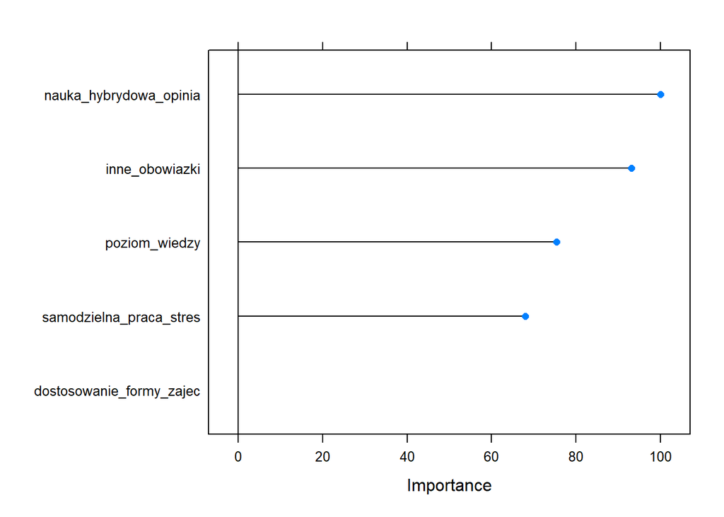

W lepszym zrozumieniu zależności pomiędzy zmienna objaśniająca a zmienna wyjściowa może pomóc analiza wykresu PDP (Partial Dependence Plot). PDP przedstawia wizualnie jak średnio każda ze zmiennych objaśniających wpływa na zmienną prognozowana. PDP utrzymuje wszystkie zmienne oprócz jednej na stałym poziomie i sprawdza jak zmiana niezamrożonego pomiaru wpływa na wartość prawdopodobieństwa przynależności do klasy. Im bardziej plaska jest funkcja PDP, tym mniejszy wpływ analizowanej zmiennej na wyniki predykcji.

Poniższe wykresy PDP przedstawiają jak średnio zmienia się prawdopodobieństwo, że student będzie zadowolony z e-learningu w zależności od odpowiedzi, jakie udzielił na poszczególne pytania. Największy skok prawdopodobieństwa, że student będzie zadowolony z e-learningu występuje przy odpowiedziach wyższych niż 4 na pierwsze pytanie. Prawdopodobieństwo, że student, który chce, aby tradycyjne nauczanie było uzupełniane zajęciami w formie zdalnej na poziomie 5 będzie zadowolony z e-learningu jest o 0.3 większe, niż na poziomie 4. W drugim pytaniu największy skok prawdopodobieństwa występuje dla wartości 4. Zmienna reprezentująca odpowiedź na pytanie o poziom wiedzy zaczyna wpływać na spadek prawdopodobieństwa zadowolenia z e-learningu od wartości 4. Każda kolejna odpowiedz wyższa o 1 wpływa na spadek prawdopodobieństwa w równym stopniu – o ok. 0.1. Wpływ stresu związanego z samodzielną pracą na spadek prawdopodobieństwa zadowolenia z e-learningu uwidacznia się już przy odpowiedzi na poziomie 3. Im wyższa odpowiedź na pytanie o dostosowanie formy zajęć przez wykładowców tym większe prawdopodobieństwo zadowolenia. Zwiększa się ono z każdą odpowiedzią w podobnym stopniu, z tym że krzywa PDP zaczyna nachylać się bardziej przy odpowiedzi równej 5.

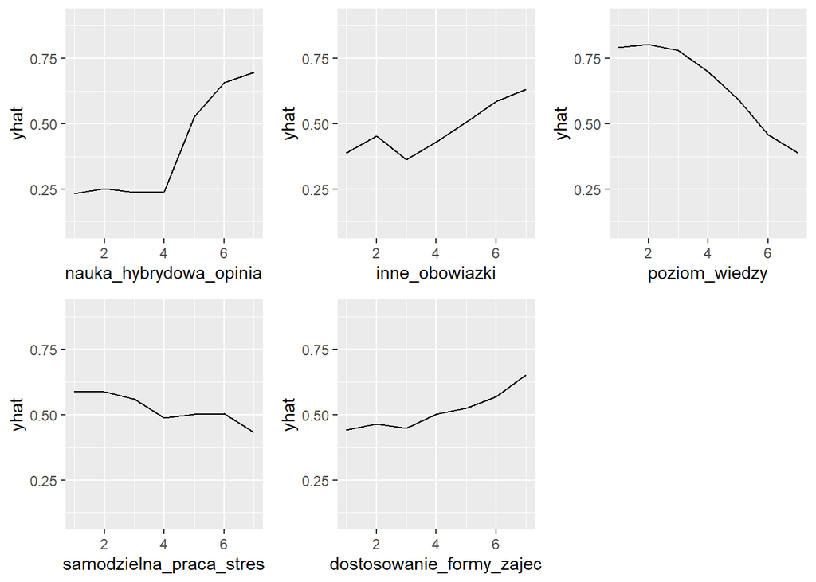

Poniższy wykres ważności predyktorów pokazuje jaki wpływ na wynik predykcji miała w stworzonym modelu każda ze zmiennych.

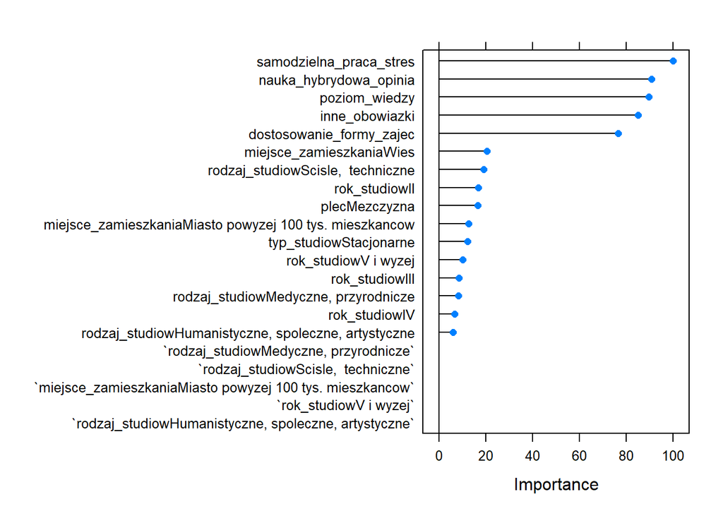

#### Lasy losowe

Inną metodą uczenia statystycznego, będąca udoskonaleniem wcześniej zastosowanego baggingu, są lasy losowe (random forests). Technika lasów losowych, podobnie jak bagging, polega na konstruowaniu wielu drzew decyzyjnych i znajdywaniu klasy dominującej, jednak przy każdym podziale drzewa brane jest pod uwagę jedynie m spośród p cech. Zapobiega to faworyzowaniu najsilniejszych predykatorów oraz tworzeniu wielu takich samych drzew. Najczęściej wybierana jest wartość równa $m = \sqrt{p}$, czyli pierwiastkowi kwadratowemu z liczby zmiennych niezależnych. Technika sprawdza się szczególnie dobrze w przypadku, gdy model budowany jest na wielu skorelowanych ze sobą zmiennych. Model lasów losowych zbudowany poniżej posiada jeden hiperparametr - liczbę cech (m) braną pod uwagę w pojedynczym podziale drzewa. Parametr zostanie poddany procesowi tuningu w celu znalezienia optymalnych wartości.

```r
control <- trainControl(method="repeatedcv", number=10, repeats=3)
mtry <- c(2:(ncol(uczacy.elearning)-2))
tunegrid <- expand.grid(.mtry=mtry)

set.seed(77)
rf <- train(ocena~.,
            data=uczacy.elearning,
            method="rf",
            tuneGrid=tunegrid,
            trControl=control)
rf
```

```
## Random Forest
##
## 161 samples
##   5 predictor
##   2 classes: '0', '1'
##
## No pre-processing
## Resampling: Cross-Validated (10 fold, repeated 3 times)
## Summary of sample sizes: 145, 146, 144, 144, 146, 145, ...
## Resampling results across tuning parameters:
##
##   mtry  Accuracy   Kappa
##   2     0.8079167  0.6155776
##   3     0.8060784  0.6117108
##   4     0.8102614  0.6202066
##
## Accuracy was used to select the optimal model using the largest value.
## The final value used for the model was mtry = 4.
```

Zbudowany model posiada dokaldnosc predykcji rowna 100% dla zbioru uczacego oraz 79.10% dla zbioru testowego, co stanowi gorszy wynik w porownaniu z poprzednimi modelami.

```
## Confusion Matrix and Statistics
##
##           Reference
## Prediction  0  1
##          0 25  7
##          1  7 28
##
##                Accuracy : 0.791
##                  95% CI : (0.6743, 0.8808)
##     No Information Rate : 0.5224
##     P-Value [Acc > NIR] : 4.906e-06
##
##                   Kappa : 0.5812
##
##  Mcnemar's Test P-Value : 1
##
##             Sensitivity : 0.7812
##             Specificity : 0.8000
##          Pos Pred Value : 0.7812
##          Neg Pred Value : 0.8000
##              Prevalence : 0.4776
##          Detection Rate : 0.3731
##    Detection Prevalence : 0.4776
##       Balanced Accuracy : 0.7906
##
##        'Positive' Class : 0
##
```

W przypadku lasów losowych również podjęto próbę zbudowania klasyfikatora uwzględniającego metryczkę. Tym razem w procesie tuningu jako optymalną wartość parametru m otrzymano 2. Poniżej znajduje się wydruk podsumowujący budowę modelu random forest dla p=10.

```r
set.seed(10)
mtry <- c(2:(ncol(uczacy.elearning)-2))
tunegrid <- expand.grid(.mtry=mtry)
rf.metryczka <- train(ocena~.,
                      data=uczacy.elearning,
                      method="rf",
                      tuneGrid=tunegrid,
                      trControl=control)
rf.metryczka
```

```
## Random Forest
##
## 161 samples
##  10 predictor
##   2 classes: '0', '1'
##
## No pre-processing
## Resampling: Cross-Validated (10 fold, repeated 3 times)
## Summary of sample sizes: 145, 144, 144, 145, 145, 146, ...
## Resampling results across tuning parameters:
##
##   mtry  Accuracy   Kappa
##   2     0.7954330  0.5879365
##   3     0.7951879  0.5874142
##   4     0.7915114  0.5801087
##   5     0.7947876  0.5866074
##   6     0.7926879  0.5823307
##   7     0.7947876  0.5866990
##   8     0.7924428  0.5820369
##   9     0.7864379  0.5703298
##
## Accuracy was used to select the optimal model using the largest value.
## The final value used for the model was mtry = 2.
```

Otrzymany model wykazuje dokładność predykcji równą 99.38% dla zbioru uczącego oraz 83.58% dla zbioru testowego, co stanowi poprawę w stosunku do poprzedniego modelu oraz względem modelu otrzymanego metodą baggingu. W przypadku lasów losowych dodanie do modelu nowych zmiennych poprawiło jakość predykcji.

```
## Confusion Matrix and Statistics
##
##           Reference
## Prediction  0  1
##          0 24  3
##          1  8 32
##
##                Accuracy : 0.8358
##                  95% CI : (0.7252, 0.9151)
##     No Information Rate : 0.5224
##     P-Value [Acc > NIR] : 7.696e-08
##
##                   Kappa : 0.6688
##
##  Mcnemar's Test P-Value : 0.2278
##
##             Sensitivity : 0.7500
##             Specificity : 0.9143
##          Pos Pred Value : 0.8889
##          Neg Pred Value : 0.8000
##              Prevalence : 0.4776
##          Detection Rate : 0.3582
##    Detection Prevalence : 0.4030
##       Balanced Accuracy : 0.8321
##
##        'Positive' Class : 0
##
```

Jakość wykorzystanych metod klasyfikacji opartych na drzewach decyzyjnych postanowiono porównać również za pomocą krzywych ROC. Im wyzsze pole pod krzywa ROC tym lepsza jakosc modelu - w tym przypadku najwieksze pole znajduje sie pod krzywa dla modelu lasow lsoowych.

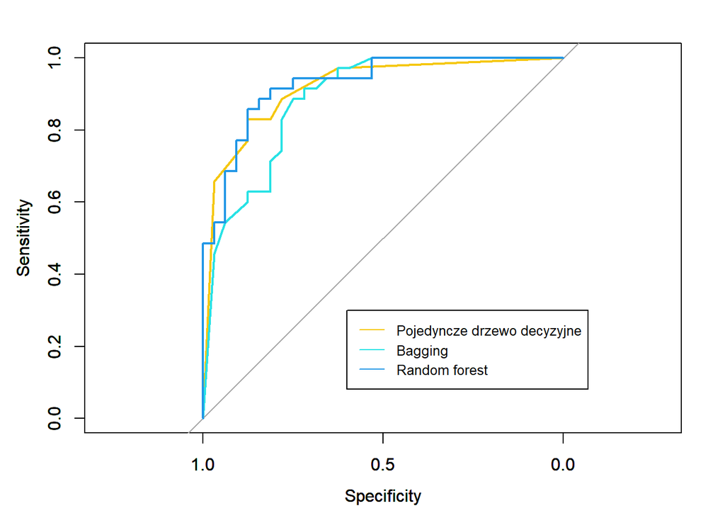

Analizując dokładność predykcji każdego z modeli drzew decyzyjnych oraz wykres krzywych ROC możemy uznać, że wszystkie modele dają zbliżone wyniki (dokładność na poziomie około 80%), jednak najlepszym pod względem obu kryteriów okazał się algorytm random forest zbudowany na danych uwzględniających metryczkę (p=10).

## Support Vector Machine

Kolejną metodą realizującą zadanie klasyfikacji jest Metoda Wektorów Nośnych - Support Vector Machines (SVM). Koncepcja metody opiera się na podziale przestrzeni p-wymiarowej za pomocą hiperpłaszczyzny, separując w ten sposób obiekty przynależące do różnych klas. Matematyczna reprezentacja hiperpłaszczyzny jest następująca:

$$\beta_0 + \beta_1X_1 + \beta_2X_2 + ... + \beta_pX_p = 0$$

Model SVM posiada jeden hiperparametr kosztu, który reguluje wagę wpływu ilości obserwacji, które znalazły się wewnątrz marginesu zaufania na błąd predykcji. Optymalna wielkość parametru została wyznaczona w procesie tuningu. Na początek stworzono model, który korzysta z jądra liniowego. Wcześniej dane zostały zcentrowane i zeskalowane.

```r
set.seed(11)
grid <- expand.grid(C = seq(0.5, 2, 0.25))
svm.linear <- train(ocena ~.,
             data = uczacy.elearning,
             method = "svmLinear",
              preProcess = c("center","scale"),
              trControl = control,
              tuneGrid=grid)
svm.linear
```

```
## Support Vector Machines with Linear Kernel
##
## 161 samples
##   5 predictor
##   2 classes: '0', '1'
##
## Pre-processing: centered (5), scaled (5)
## Resampling: Cross-Validated (10 fold, repeated 3 times)
## Summary of sample sizes: 146, 145, 146, 146, 145, 145, ...
## Resampling results across tuning parameters:
##
##   C     Accuracy   Kappa
##   0.50  0.8301879  0.6608591
##   0.75  0.8261438  0.6528398
##   1.00  0.8240605  0.6486732
##   1.25  0.8261438  0.6528398
##   1.50  0.8261438  0.6528398
##   1.75  0.8281046  0.6566924
##   2.00  0.8281046  0.6566924
##
## Accuracy was used to select the optimal model using the largest value.
## The final value used for the model was C = 0.5.
```

Na poniższym wykresie ukazano wyniki tuningu hiperparametru kosztu, czyli jak zmienia się dokładność predykcji walidacji krzyżowej w zależności od wartości parametru.

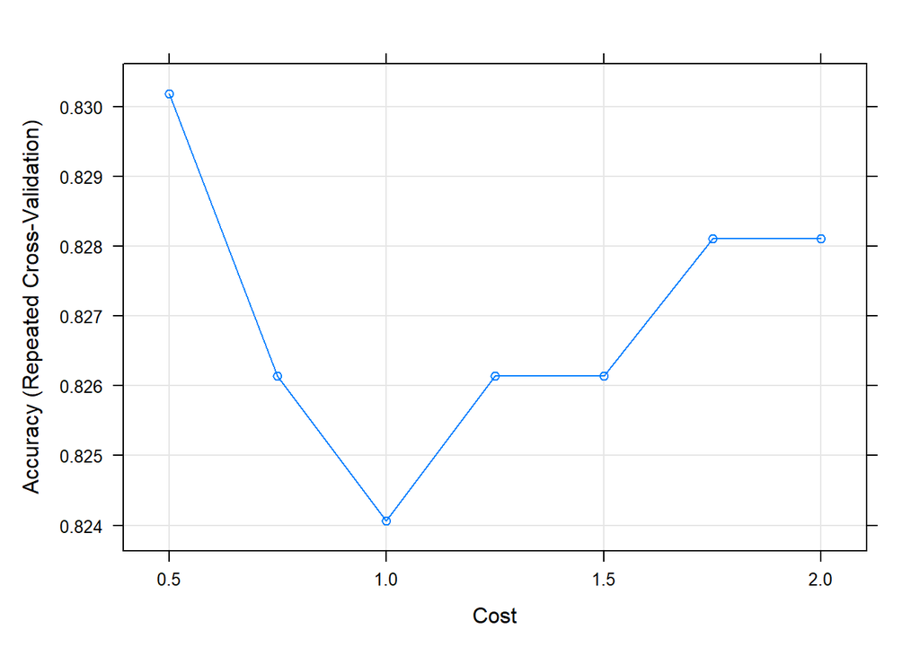

Model SVM z jadrem liniowym posiada dokładność predykcji równą 83.85% na zbiorze uczącym oraz 77.61% na zbiorze testowym, co jest gorszym wynikiem w porownaniu do wczesniejszych modeli ML.

```
## Confusion Matrix and Statistics
##
##           Reference
## Prediction  0  1
##          0 24  7
##          1  8 28
##
##                Accuracy : 0.7761
##                  95% CI : (0.6578, 0.8689)
##     No Information Rate : 0.5224
##     P-Value [Acc > NIR] : 1.64e-05
##
##                   Kappa : 0.5507
##
##  Mcnemar's Test P-Value : 1
##
##             Sensitivity : 0.7500
##             Specificity : 0.8000
##          Pos Pred Value : 0.7742
##          Neg Pred Value : 0.7778
##              Prevalence : 0.4776
##          Detection Rate : 0.3582
##    Detection Prevalence : 0.4627
##       Balanced Accuracy : 0.7750
##
##        'Positive' Class : 0
##
```

Zbudowano również model SVM z jądrem radialnym. Wyniki działania algorytmu przedstawia poniższy wydruk. Tym razem dostosowac nalezalo wartosci dwoch hiperparametrow - kosztu C oraz parametru sigma, ktory kontroluje poziom nieliniowosci wprowadzanej do modelu. Dokladnosc predykcji w zaleznosci od wartosci hiperparametrow przedsatwia ponizszy wykres. Ostatecznie do modelu wybrano C=1 oraz sigma=0.2.

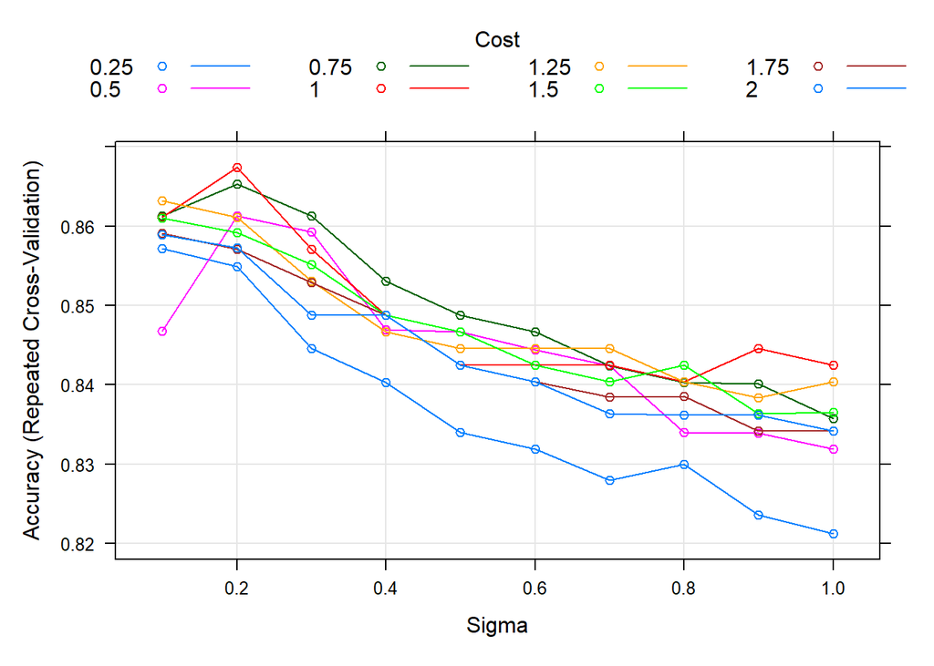

```r
grid <- expand.grid(sigma = seq(0.1, 1, 0.1),
                    C = seq(0.25, 2, 0.25))
set.seed(45)
svm.radial <- train(ocena ~.,
                  data = uczacy.elearning,
                  method = "svmRadial",
                  trControl = control,
                  preProcess = c("center","scale"),
                  tuneGrid = grid)

plot(svm.radial)
```

Model SVM z jadrem radialnym osiagnal dokładność predykcji równą 91.30% na zbiorze uczącym oraz 76.12% na zbiorze testowym. Lepsze wlasciwosci prognostyczne na naszych danych okazuje sie miec model SVM z jadrem liniowym.

```
## Confusion Matrix and Statistics
##
##           Reference
## Prediction  0  1
##          0 24  8
##          1  8 27
##
##                Accuracy : 0.7612
##                  95% CI : (0.6414, 0.8569)
##     No Information Rate : 0.5224
##     P-Value [Acc > NIR] : 5.056e-05
##
##                   Kappa : 0.5214
##
##  Mcnemar's Test P-Value : 1
##
##             Sensitivity : 0.7500
##             Specificity : 0.7714
##          Pos Pred Value : 0.7500
##          Neg Pred Value : 0.7714
##              Prevalence : 0.4776
##          Detection Rate : 0.3582
##    Detection Prevalence : 0.4776
##       Balanced Accuracy : 0.7607
##
##        'Positive' Class : 0
##
```

## Porownanie modeli

W ponizszej tabeli zostaly zebrane wartosci dokaldnosci predykcji na zbiorach testowych dla kazdego ze stworzonych modeli. Wszystkie modele posiadaja dosc wysokie wspolczynniki dokladnosci predykcji. Najlepsze wlasciwosci prognostyczne okazuje sie miec naiwny klasyfikator bayesowski. Najslabiej w prognozowaniu spisaly sie modele SVM.

```
##               model test.acc
## 1               NBC    0.896
## 2       Single tree    0.821
## 3       Bagging p=5    0.821
## 4      Bagging p=10    0.806
## 5 Random forest p=5    0.791
## 6        SVM Linear    0.776
## 7        SVM radial    0.761
```

## Podsumowanie

W powyzszym badaniu zostala podjeta proba zbadania efektywnosci zdalnego nauczania podczas pandemii COVID-19 z perspektywy studentow. Analiza odpowiedzi ankietowanych poszerzona o analize skupien oraz konstrukcje wykresow PCP pozwolila zidentyfikowac grupy studentow o roznych odswiadczeniach zwiazanych ze studiowaniem na odleglosc. Glownym celem badania bylo znalezienie modeli uczenia maszynowego, ktore beda w stanie jak najlepiej przewidywac satysfakcje studenta z e-learningu na podstawie zwiazanych z nim doswiadczen. Udalo sie zbudowac szereg modeli dajacych zadowalajace a nawet bardzo dobre wyniki predykcji (dokladnosc predykcji rzedu 80-90%). Jednoczesnie zidentyfikowano najistotniejesze czynniki wplywajace na zadowolenie studentow z e-learningu. Wnioskujemy, ze zalezy ono zarowno od czynnikow psychologicznych - motywacja do nauki czy tez stres wywolany duza iloscia samodzielnej pracy, od preferencji oraz czynnikow zewnetrznych. Wplyw na zadowolenie maja rowniez czynniki osobiste, takie jak miejsce zamieszkania czy rodzaj studiow.